# Working with Character Values

Author

Jianyuan(Andy) Hu

Published

October 19, 2024

# Purpose

This document is created to better illustrate and teach SQL (MySQL) for students in my course: Introduction to SQL and Database Management Techniques.

# Reference

This document is based on Murach, J. (2023). Murach’s MySQL (4th Edition).

Default database in this document is “ex”.

Other databases included in the simulation MySQL server:

- om
- ap

This document is based on MySQL 8.4.

MySQL references for string manipulation: https://dev.mysql.com/doc/refman/8.4/en/string-functions.html

# Regular Expression

A regular expression (shortened as regex or regexp), sometimes referred to as rational expression, is a sequence of characters that specifies a match pattern in text.

There is no universal guide for regex, as each implementation has their own dialoect/flavour. Here is a one that help you to get started. [MySQL Regex Syntax](https://dev.mysql.com/doc/refman/8.4/en/regexp.html#regexp-syntax)

# String Extraction

## SUBSTRING_INDEX

[SUBSTRING_INDEX()](https://dev.mysql.com/doc/refman/8.4/en/string-functions.html#function_substring-index): Return a substring from a string before the specified number of occurrences of the delimiter.

```sql
SELECT emp_name,
    SUBSTRING_INDEX(emp_name, ' ', 1) AS first_name,
    SUBSTRING_INDEX(emp_name, ' ', -1) AS last_name
FROM string_sample
```

5 records

| emp_name | first_name | last_name |
| --- | --- | --- |
| Lizbeth Darien | Lizbeth | Darien |
| Darnell O’Sullivan | Darnell | O’Sullivan |
| Lance Pinos-Potter | Lance | Pinos-Potter |
| Jean Paul Renard | Jean | Renard |
| Alisha von Strump | Alisha | Strump |

## SUBSTRING

[SUBSTRING()](https://dev.mysql.com/doc/refman/8.4/en/string-functions.html#function_substring): Return the substring between 2 position indexes.

```sql
SELECT emp_name,
    SUBSTRING(emp_name, 1, LOCATE(' ', emp_name) - 1) AS first_name,
    SUBSTRING(emp_name, LOCATE(' ', emp_name) + 1) AS last_name
FROM string_sample
```

5 records

| emp_name | first_name | last_name |
| --- | --- | --- |
| Lizbeth Darien | Lizbeth | Darien |
| Darnell O’Sullivan | Darnell | O’Sullivan |
| Lance Pinos-Potter | Lance | Pinos-Potter |
| Jean Paul Renard | Jean | Paul Renard |
| Alisha von Strump | Alisha | von Strump |

## REGEXP_SUBSTR

[REGEXP_SUBSTR()](https://dev.mysql.com/doc/refman/8.4/en/regexp.html#function_regexp-substr): It is the same as SUBSTRING, but use the regular expression to mathc instead of position index.

For more information about regular expression, see Regular Expression

```sql
SELECT emp_name,
  -- match any capital letter, starting at position 3 after the match, return the position 2 after the starting point
  REGEXP_SUBSTR(emp_name, '[A-Z]', 3, 2)
FROM string_sample
```

5 records

| emp_name | REGEXP_SUBSTR(emp_name, ‘[A-Z]’, 3, 2) |
| --- | --- |
| Lizbeth Darien | b |
| Darnell O’Sullivan | n |
| Lance Pinos-Potter | c |
| Jean Paul Renard | n |
| Alisha von Strump | s |

# String Mutation

## LPAD/RPAD

Make sure all text strings are extended to the same length, either:

- [LPAD()](https://dev.mysql.com/doc/refman/8.4/en/string-functions.html#function_lpad): add characters on the left hand.
- [RPAD()](https://dev.mysql.com/doc/refman/8.4/en/string-functions.html#function_rpad): add characters on the right hand.

Example: the following adds leading 0s to emplid Before any update to emp_id:

```sql
SELECT emp_id, emp_name
FROM string_sample
ORDER BY emp_id
```

5 records

| emp_id | emp_name |
| --- | --- |
| 1 | Lizbeth Darien |
| 17 | Lance Pinos-Potter |
| 2 | Darnell O’Sullivan |
| 20 | Jean Paul Renard |
| 3 | Alisha von Strump |

After padding 0s added to emp_id:

```sql
SELECT LPAD(emp_id, 2, '0') AS emp_id, emp_name
FROM string_sample
ORDER BY emp_id
```

5 records

| emp_id | emp_name |
| --- | --- |
| 01 | Lizbeth Darien |
| 02 | Darnell O’Sullivan |
| 03 | Alisha von Strump |
| 17 | Lance Pinos-Potter |
| 20 | Jean Paul Renard |

If adding 0s to the right side

```sql
SELECT RPAD(emp_id, 3, '0') AS emp_id, emp_name
FROM string_sample
ORDER BY emp_id
```

5 records

| emp_id | emp_name |
| --- | --- |
| 100 | Lizbeth Darien |
| 170 | Lance Pinos-Potter |
| 200 | Darnell O’Sullivan |
| 200 | Jean Paul Renard |
| 300 | Alisha von Strump |

## LOWER/UPPER

[LOWER()](https://dev.mysql.com/doc/refman/8.4/en/string-functions.html#function_lower): Returns the string str with all characters changed to lowercase.

[UPPER()](https://dev.mysql.com/doc/refman/8.4/en/string-functions.html#function_upper): Returns the string str with all characters changed to uppercase

```sql
SELECT emp_name,
  LOWER(emp_name) AS lowercase,
  UPPER(emp_name) AS uppercase
FROM string_sample
```

5 records

| emp_name | lowercase | uppercase |
| --- | --- | --- |
| Lizbeth Darien | lizbeth darien | LIZBETH DARIEN |
| Darnell O’Sullivan | darnell o’sullivan | DARNELL O’SULLIVAN |
| Lance Pinos-Potter | lance pinos-potter | LANCE PINOS-POTTER |
| Jean Paul Renard | jean paul renard | JEAN PAUL RENARD |
| Alisha von Strump | alisha von strump | ALISHA VON STRUMP |

## REPLACE

[REPLACE()](https://dev.mysql.com/doc/refman/8.4/en/string-functions.html#function_replace): Replace occurrences of a specified string.

```sql
SELECT emp_name,
  REPLACE(emp_name, ' ', ' <=> ') AS new_name
FROM string_sample
```

5 records

| emp_name | new_name |
| --- | --- |
| Lizbeth Darien | Lizbeth <=> Darien |
| Darnell O’Sullivan | Darnell <=> O’Sullivan |
| Lance Pinos-Potter | Lance <=> Pinos-Potter |
| Jean Paul Renard | Jean <=> Paul <=> Renard |
| Alisha von Strump | Alisha <=> von <=> Strump |

## REGEXP_REPLACE

[REGEXP_REPLACE()](https://dev.mysql.com/doc/refman/8.4/en/regexp.html#function_regexp-replace): Similar as replace, but use regex to match and identify the part to replace.

```sql
SELECT emp_name,
  REGEXP_REPLACE(emp_name, '^\w', ' <=> ') AS new_name
FROM string_sample
```

5 records

| emp_name | new_name |
| --- | --- |
| Lizbeth Darien | Lizbeth Darien |
| Darnell O’Sullivan | Darnell O’Sullivan |
| Lance Pinos-Potter | Lance Pinos-Potter |
| Jean Paul Renard | Jean Paul Renard |
| Alisha von Strump | Alisha von Strump |

## CONCAT

[CONCAT()](https://dev.mysql.com/doc/refman/8.4/en/string-functions.html#function_concat): Glue all argument strings together as 1 string.

[CONCAT_WS](https://dev.mysql.com/doc/refman/8.4/en/string-functions.html#function_concat-ws): Glue all argument strings With Separators.

```sql
SELECT emp_name,
    SUBSTRING_INDEX(emp_name, ' ', 1) AS first_name,
    SUBSTRING_INDEX(emp_name, ' ', -1) AS last_name,
    CONCAT_WS(', ',
      SUBSTRING_INDEX(emp_name, ' ', -1),
      SUBSTRING_INDEX(emp_name, ' ', 1)) AS new_name,
    SUBSTRING(SUBSTRING_INDEX(emp_name, ' ', 1), 1, 1) AS initial_first_name,
    SUBSTRING(SUBSTRING_INDEX(emp_name, ' ', -1), 1, 1) AS initial_last_name,
    CONCAT(
      SUBSTRING(SUBSTRING_INDEX(emp_name, ' ', 1), 1, 1),
      SUBSTRING(SUBSTRING_INDEX(emp_name, ' ', -1), 1, 1)) AS initial
FROM string_sample
```

5 records

| emp_name | first_name | last_name | new_name | initial_first_name | initial_last_name | initial |
| --- | --- | --- | --- | --- | --- | --- |
| Lizbeth Darien | Lizbeth | Darien | Darien, Lizbeth | L | D | LD |
| Darnell O’Sullivan | Darnell | O’Sullivan | O’Sullivan, Darnell | D | O | DO |
| Lance Pinos-Potter | Lance | Pinos-Potter | Pinos-Potter, Lance | L | P | LP |
| Jean Paul Renard | Jean | Renard | Renard, Jean | J | R | JR |
| Alisha von Strump | Alisha | Strump | Strump, Alisha | A | S | AS |

# String Search

## Partial Match (LIKE)

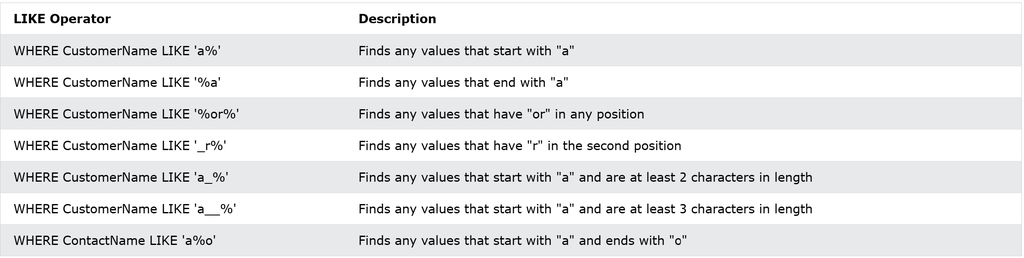

[Source](https://www.w3schools.com/mysql/mysql_like.asp)

Example: return all employee names that has letter b or p:

```sql
SELECT emp_name
FROM string_sample
WHERE emp_name LIKE '%b%' OR emp_name LIKE '%p%'
```

4 records

| emp_name |
| --- |
| Lizbeth Darien |
| Lance Pinos-Potter |
| Jean Paul Renard |
| Alisha von Strump |

If you want to enable case sensitive search:

```sql
SELECT emp_name
FROM string_sample
WHERE emp_name LIKE '%b%' OR emp_name LIKE BINARY '%p%'
```

2 records

| emp_name |
| --- |
| Lizbeth Darien |
| Alisha von Strump |

## LOCATE

[LOCATE()](https://dev.mysql.com/doc/refman/8.4/en/string-functions.html#function_locate): Return the position of the first occurrence of substring

```sql
SELECT emp_name,
    LOCATE(' ', emp_name) AS first_space,
    LOCATE(' ', emp_name, LOCATE(' ', emp_name) + 1) AS second_space
FROM string_sample
```

5 records

| emp_name | first_space | second_space |
| --- | --- | --- |
| Lizbeth Darien | 8 | 0 |
| Darnell O’Sullivan | 8 | 0 |
| Lance Pinos-Potter | 6 | 0 |
| Jean Paul Renard | 5 | 10 |
| Alisha von Strump | 7 | 11 |

## REGEXP_LIKE

You can also subset values based on regex pattern matching.

For example, let’s find out all of the table names with pattern like “COLUMNS_” on the server.

```sql
SELECT TABLE_CATALOG, TABLE_SCHEMA, TABLE_NAME, COLUMN_NAME
FROM information_schema.COLUMNS
WHERE REGEXP_LIKE(TABLE_NAME, '^COLUMNS_')
```

13 records

| TABLE_CATALOG | TABLE_SCHEMA | TABLE_NAME | COLUMN_NAME |
| --- | --- | --- | --- |
| def | information_schema | COLUMNS_EXTENSIONS | COLUMN_NAME |
| def | information_schema | COLUMNS_EXTENSIONS | ENGINE_ATTRIBUTE |
| def | information_schema | COLUMNS_EXTENSIONS | SECONDARY_ENGINE_ATTRIBUTE |
| def | information_schema | COLUMNS_EXTENSIONS | TABLE_CATALOG |
| def | information_schema | COLUMNS_EXTENSIONS | TABLE_NAME |
| def | information_schema | COLUMNS_EXTENSIONS | TABLE_SCHEMA |
| def | mysql | columns_priv | Column_name |
| def | mysql | columns_priv | Column_priv |
| def | mysql | columns_priv | Db |
| def | mysql | columns_priv | Host |
| def | mysql | columns_priv | Table_name |
| def | mysql | columns_priv | Timestamp |
| def | mysql | columns_priv | User |

Next example, let’s find out all of the column names that has word date at the end.

```sql
SELECT TABLE_CATALOG, TABLE_SCHEMA, TABLE_NAME, COLUMN_NAME
FROM information_schema.COLUMNS
WHERE TABLE_NAME = 'invoices' AND REGEXP_LIKE(COLUMN_NAME, 'date$')
```

6 records

| TABLE_CATALOG | TABLE_SCHEMA | TABLE_NAME | COLUMN_NAME |
| --- | --- | --- | --- |
| def | ap | invoices | invoice_date |
| def | ap | invoices | invoice_due_date |
| def | ap | invoices | payment_date |
| def | ap1 | invoices | invoice_date |
| def | ap1 | invoices | invoice_due_date |
| def | ap1 | invoices | payment_date |

```sql
SELECT TABLE_CATALOG,
  TABLE_SCHEMA,
  TABLE_NAME,
  COLUMN_NAME,
  REGEXP_INSTR(COLUMN_NAME, 'date') AS REGEXP_INSTR
FROM information_schema.COLUMNS
WHERE TABLE_NAME = 'invoices'
```

Displaying records 1 - 15

| TABLE_CATALOG | TABLE_SCHEMA | TABLE_NAME | COLUMN_NAME | REGEXP_INSTR |
| --- | --- | --- | --- | --- |
| def | ap | invoices | credit_total | 0 |
| def | ap | invoices | invoice_date | 9 |
| def | ap | invoices | invoice_due_date | 13 |
| def | ap | invoices | invoice_id | 0 |
| def | ap | invoices | invoice_number | 0 |
| def | ap | invoices | invoice_total | 0 |
| def | ap | invoices | payment_date | 9 |
| def | ap | invoices | payment_total | 0 |
| def | ap | invoices | terms_id | 0 |
| def | ap | invoices | vendor_id | 0 |
| def | ap1 | invoices | credit_total | 0 |
| def | ap1 | invoices | invoice_date | 9 |
| def | ap1 | invoices | invoice_due_date | 13 |
| def | ap1 | invoices | invoice_id | 0 |
| def | ap1 | invoices | invoice_number | 0 |